# tmps4_stgfm

## **What Is DBSCAN?**

[**DBSCAN**](https://en.wikipedia.org/wiki/DBSCAN) (Density-Based Spatial Clustering of Applications with Noise) is a density-based clustering algorithm proposed by [Martin Ester](https://en.wikipedia.org/wiki/Martin_Ester), [Hans-Peter Kriegel](https://en.wikipedia.org/wiki/Hans-Peter_Kriegel), [Jörg Sander](https://en.wikipedia.org/w/index.php?title=J%C3%B6rg_Sander&action=edit&redlink=1), and [Xiaowei Xu](https://en.wikipedia.org/w/index.php?title=Xiaowei_Xu&action=edit&redlink=1) in 1996. It is used widely for identifying clusters of varying shapes and separating out noise. Unlike K-means, DBSCAN does not require prior specification of the number of clusters, since it relies on a fixed density threshold to define clusters, which makes it perform best when clusters have similar density.

DBSCAN is well-suited for datasets containing clusters of **arbitrary shape, but not of varying density** and performs well in the presence of noise and outliers.

**Hyperparameters**

*ε* - a threshold for distance

minPts - a threshold for a minimum number of points

**Initial Definitions**

1. Core Point: A point that has at least minPts points within distance *ε* of it (including the point).
2. Directly Reachable Point: A point *q* is *directly reachable* from core point *p* wrt.

> *ε* and minPts if point *q* is within distance *ε* from *p*. Points are only said to be directly reachable from core points.

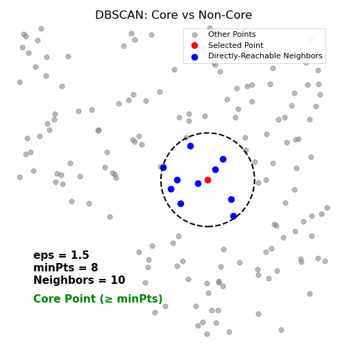

*GIF 1 : Visualising Core Points*

3. Border Point: A point *q* is a border point if it is not a core point, but it is directly reachable from a core point p.
4. Density Reachable: A point *q* is *density reachable* from *p* if there is a chain of points *p*<sub>1</sub>, ..., *p<sub>n</sub>* with *p*<sub>1</sub> = *p* and *p<sub>n</sub>* = *q*, where each *p<sub>i</sub>*<sub>+1</sub> is directly reachable from *p<sub>i</sub>*. Note that this implies that *p*<sub>1</sub>,*p*<sub>2</sub> ..., *p<sub>n-1</sub>* must be core points.

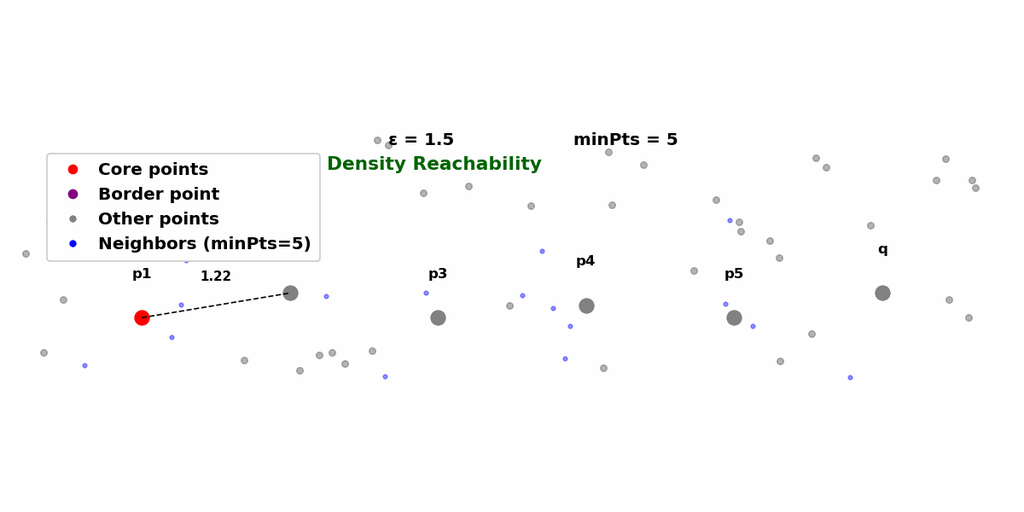

*GIF 2 : Visualising Density Reachability*

5. Density Connected: A point p is density- connected to a point q wrt. ε and minPts if there is a point ‘o’ such that both, p and q are density-reachable from o wrt.

> ε and minPts.

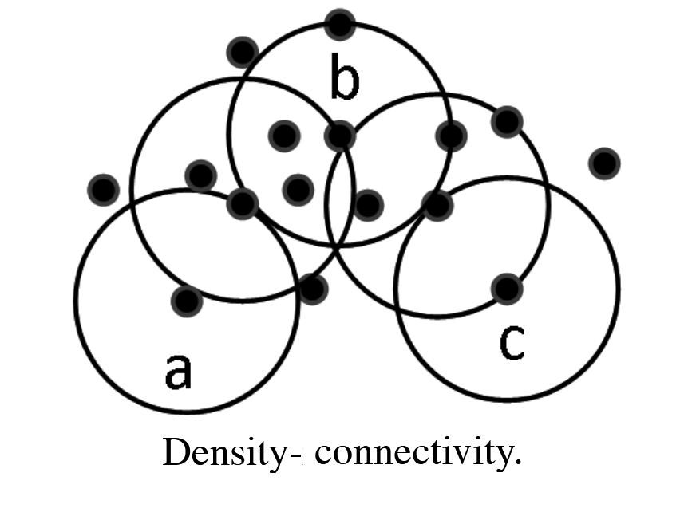

*Image 1 : Visualising Density Connectivity*

6. Cluster: A cluster C wrt. ε and minPts is a subset of points satisfying the following conditions:

> 1)All points within the cluster are mutually density-connected.

> 2)If a point is density-reachable from some point of the cluster, it is part of the cluster as well.
7. *Outliers* or *noise points:* All points that are not reachable from any other point. (not in any cluster)

Start by choosing a threshold for distance (*ε* ) and minimum number of points (minPts).

**Algorithm**

The algorithm is roughly distributed in the following steps:

1. Identify each point as a core point, border point, or noise point.
2. For each unvisited core point:
   1. Create a new cluster label.
   2. Add all unclustered points that are density reachable from the current core point in the newly created cluster.
   3. **Recursively** expand the cluster by:
- Visiting each directly density-reachable neighbor of the core point.
- If that neighbor is also a core point, apply the same process recursively to its neighbors.
- Continue this process until **no more unclustered points in the ε-neighborhood of any core point** can be added to the cluster.
3. For each unclustered border point, assign it the respective cluster of the current core point.
4. The noise points are not assigned any clusters and are discarded or assigned a cluster label of -1.

### **#Sample Dataset**

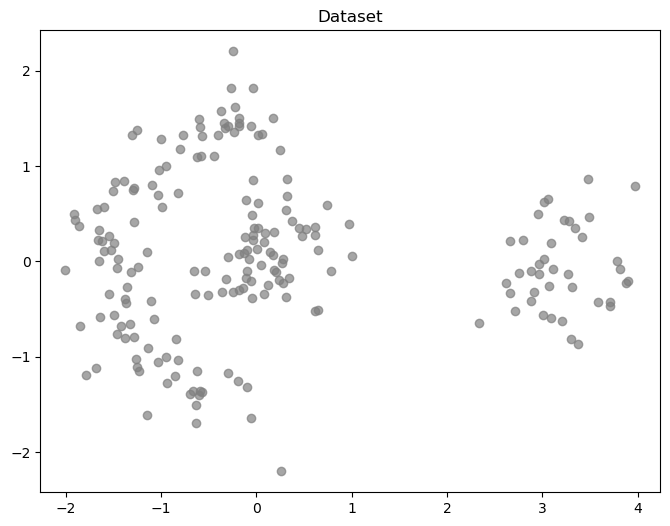

*Image 2: Sample Data distribution*

## **Understanding Clusters**

The definition of density connectedness has been chosen in such a way that all points belonging to an unbroken chain of density-reachability and hence belonging to the same dense region are discovered by the recursive search of the algorithm.

Intuitively, a cluster is defined to be a set of density-connected points that is maximal wrt. density-reachability.

Lemma 1 - Let p be a core point. Then the set O = {o | o ∈D and o is density-reachable from p wrt. ε and minPts } is a cluster wrt. ε and minPts .

Lemma 2- Let C be a cluster wrt. ε and minPts and let p be any core point in C. Then C equals to the set O = {o | o is density-reachable from p wrt. ε and minPts }.

This means that, once we start from a core point, we **recursively add all points that can be density-reached from it**, and that set forms the entire cluster. No further points can be added without violating the rules of density-based connectivity.

## **1. Identify each point as core/border/noise**

Note: The *assumption of noise* is important here: real data is messy and has outliers, corrupt data, and noise.

### **Intuition**

The core idea behind DBSCAN is its center-based approach to density. In the center-based approach, density is estimated for a particular point in the data set by counting the number of points within a specified radius, ε, of that point. This includes the point itself. The center-based approach to density allows us to classify a point as being (1) in the interior of a dense region (a core point), (2) on the edge of a dense region (a border point), or (3) in a sparsely occupied region (a noise or background point).

A core point solidifies the presence of a local density. On the other hand, a border point can be thought of as supporting members of a cluster. Noise points are considered unclassifiable under the given density parameters as they lie in regions of insufficient local density.

## **2a). Assigning and Expanding Clusters**

We start by choosing a random point. For each point we randomly choose, if it has been unvisited, we check if it is a core point. For this unvisited core point p, we initialize a new cluster and assign it a label.

For each neighbor q in the ε-neighborhood of this core point p:

## **2b). Expanding Clusters through Density-Reachable Points**

**Transitive Density Connectivity:**  
A key property DBSCAN uses is that **if point A is density-reachable to B, and B to C, then A and C are part of the same cluster** (under certain conditions). So expansion propagates through chains of core points.

**Grow the cluster iteratively:**

- If it is a core point, all unclustered points in **its ε-neighborhood are also added to the cluster**. Why?

> Since all points in **ε-neighborhood** of q are directly reachable to q (q is a core point), and q is density reachable to p, and p and q being both core points ensures that all points in **ε-neighborhood** of q are density-connected to p.

For this core point q, we recursively repeat steps 2a,2b, and 3 of the algorithm until no more unclustered point in the **ε-neighborhood** of this core point q can be added to the cluster.

## **3). Adding border points**

> If q is a border point, it is added to the current cluster, but **its own neighbours are not used to expand the cluster further**. Border points do not expand the cluster. Why?

> Because the neighbours of q are not linked to p through density-reachability, the reason being that q is not a core point, and hence the condition for density-reachability is not satisfied.

> If it has already been visited or belongs to another cluster, it is skipped.

> This implies that for an unvisited core point p, its corresponding cluster will include not only its own unvisited **ε-neighborhood** but also respective **ε-neighborhoods** of all core points in its neighbourhood p.

**Expansion stops naturally:**  
The process of adding new points stops when no more density-reachable points are found—i.e. when you’ve exhausted the network of core points connected through overlapping ε-neighborhoods.

## **4). Dealing and interpreting noise points(outliers)**

Noise points are outliers that are **too isolated** to be part of a cluster. They lie in **low-density regions** of the dataset and do not contribute to the growth of any dense region (cluster). Depending on our requirements and preferences, we can either discard them completely or assign them a label ‘-1’,

NOTE: Whether a point is a noise point(outlier) can change on the basis of our parameters ε and minPts. For a different set of parameters, they may be classified as a part of a cluster.

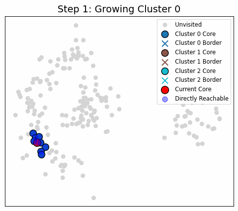

*GIF 3: Cluster formation*

### **#Selection of** ε **and** minPts

## The basic approach is to look at the behavior of the distance from a point to its k<sup>th</sup> nearest neighbor, which we will call the k-dist. For points that belong to some cluster, the value of k-dist will be small if k is not larger than the cluster size.

## Note that there will be some variation, depending on the density of the cluster and the random distribution of points, but on average, the range of variation will not be huge if the cluster densities are not radically different.

## However, for points that are not in a cluster, such as noise points, the k-dist will be relatively large. Therefore, if we compute the k-dist for all the data points for some k, sort them in increasing order, and then plot the sorted values, we expect to see a sharp change at the value of k-dist that corresponds to a suitable value of ε. If we select this distance as the ε parameter and take the value of k as the minPts parameter, then points for which k-dist is less than ε will be labeled as core points, while other points will be labeled as noise or border points.

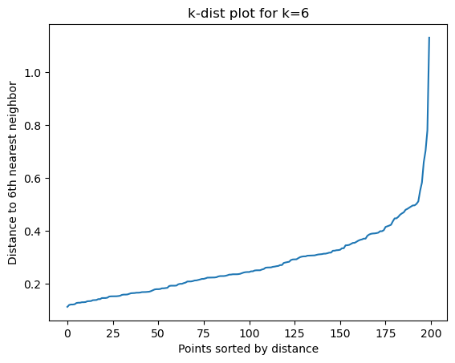

*Image 3: kdist plot for k=6*

**Time and Space Complexity**

The basic time complexity of the DBSCAN algorithm is O(m × time to find points in the ε -neighborhood), where m is the number of points. In the worst case, this complexity is O(m2). However, in low-dimensional spaces, there are data structures, such as kd-trees, that allow efficient retrieval of all points within a given distance of a specified point, and the time complexity can be as low as O(m log m). The space requirement of DBSCAN, even for

high-dimensional data is O(m) because it is only necessary to keep a small amount of data for each point, i.e., the cluster label and the identification of each point as a core, border, or noise point.

**5) Conclusion**

### **5.1 Results**

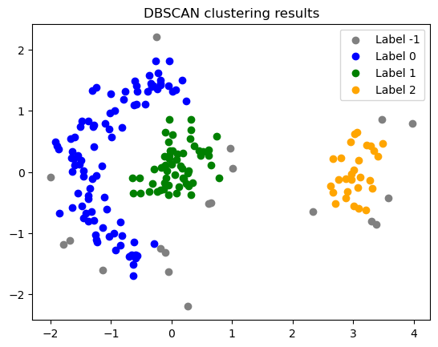

*Image 4: DBSCAN clustering results on given data*

Corresponding KMeans clustering results:

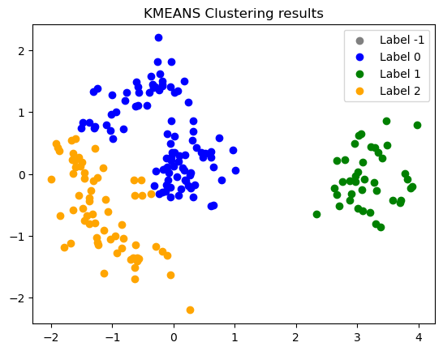

*Image 5: KMeans algorithm clustering results on given data*

This clearly shows that DBSCAN can handle clusters of arbitrary shapes and sizes without specifying the number of clusters beforehand, while KMeans failed in separating noncircular clusters from circular ones because it is a predominantly Euclidean-distance-based algorithm.

Because DBSCAN uses a density-based definition of a cluster, it is relatively resistant to noise.

### **5.2 Weaknesses of DBSCAN**

- DBSCAN can have trouble with density if the density of clusters varies widely.
- It also has trouble with high-dimensional data because density is more difficult to define for such data.
- DBSCAN can be expensive when the computation of nearest neighbors requires computing all pairwise proximities, as is usually the case for high-dimensional data.
- DBSCAN is sensitive to parameter choice(**ε and min_pts**). A poor choice of parameters can merge separate clusters, split a single cluster into many, or mislabel many points as noise.  
  There's **no universal rule** to pick ε, especially for complex or high-dimensional data.

### **5.3 Improvements & Extensions of DBSCAN**

#### G-DBSCAN (Generalized DBSCAN) Allows custom distance functions, enabling categorical data clustering and improves on DBSCAN’s numeric-only limitation.

- For varying densities, HDBSCAN is used widely.
- SNN Density- based on shared nearest neighbour similarity- can be combined with the DBSCAN algorithm to create a new clustering algorithm. SNN uses **neighbor overlap**, not just raw density, and is better with higher dimensional data.
- To overcome the difficulty in using one set of global parameters in clustering analysis, a cluster analysis method called OPTICS was proposed. OPTICS does not explicitly produce a data set clustering. Instead, it outputs a cluster ordering.

[The Scikitlearn documentation of DBSCAN](https://scikit-learn.org/stable/modules/generated/sklearn.cluster.DBSCAN.html) allows one to change the metric to use when calculating the distance between instances and also the algorithm used to search for the nearest neighbours of the instances.

For calculating distance, the **Minkowski distance** is a **generalized distance metric** used to measure the distance between two points in a normed vector space.

For two points X=(x<sub>1</sub>,x<sub>2</sub>,....x<sub>n</sub>)and Y=(y<sub>1</sub>,y<sub>2</sub>,....y<sub>n</sub>), the Minkowski distance is defined as:

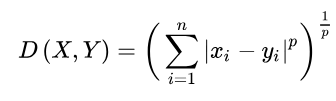

Where:

- p is the **order** of the norm.
- p ≥1
- p=2 by default in Scikitlearn, and can be changed to any float value

**#Resources and References**

- [DBSCAN Paper](https://www.dbs.ifi.lmu.de/Publikationen/Papers/KDD-96.final.frame.pdf)
- [How DBSCAN works](https://www.youtube.com/watch?v=wbS1OXkA5uc)
- [**"Data Clustering: Algorithms and Applications"** by Charu C. Aggarwal & Chandan K. Reddy](https://people.cs.vt.edu/~reddy/papers/DCBOOK.pdf)
- **"Data Mining: Concepts and Techniques" by Jiawei Han, Micheline Kamber, Jian Pei**
- [DBSCAN implementation from scratch in Python](https://www.youtube.com/watch?v=PbU3JwRdAAw)
- [Interview questions on DBSCAN](https://www.youtube.com/watch?v=cCw1yqqvOCI)